# Tabular Data Foundations

## Relational data and joins

```r
> # install.packages("nycflights13")
> library(nycflights13)
```

### Relational data

```r
> head(flights)
# A tibble: 6 × 19
   year month   day dep_time sched_dep_time dep_delay arr_time sched_arr_time
  <int> <int> <int>    <int>          <int>     <dbl>    <int>          <int>
1  2013     1     1      517            515         2      830            819
2  2013     1     1      533            529         4      850            830
3  2013     1     1      542            540         2      923            850
4  2013     1     1      544            545        -1     1004           1022
5  2013     1     1      554            600        -6      812            837
6  2013     1     1      554            558        -4      740            728
# … with 11 more variables: arr_delay <dbl>, carrier <chr>, flight <int>,
#   tailnum <chr>, origin <chr>, dest <chr>, air_time <dbl>, distance <dbl>,
#   hour <dbl>, minute <dbl>, time_hour <dttm>
```

```r
> head(airports)
# A tibble: 6 × 8
  faa   name                             lat   lon   alt    tz dst   tzone
  <chr> <chr>                          <dbl> <dbl> <dbl> <dbl> <chr> <chr>
1 04G   Lansdowne Airport               41.1 -80.6  1044    -5 A     America/Ne…
2 06A   Moton Field Municipal Airport   32.5 -85.7   264    -6 A     America/Ch…
3 06C   Schaumburg Regional             42.0 -88.1   801    -6 A     America/Ch…
4 06N   Randall Airport                 41.4 -74.4   523    -5 A     America/Ne…
5 09J   Jekyll Island Airport           31.1 -81.4    11    -5 A     America/Ne…
6 0A9   Elizabethton Municipal Airport  36.4 -82.2  1593    -5 A     America/Ne…
```

```r
> head(planes)
# A tibble: 6 × 9
  tailnum  year type           manufacturer   model  engines seats speed engine
  <chr>   <int> <chr>          <chr>          <chr>    <int> <int> <int> <chr>
1 N10156   2004 Fixed wing mu… EMBRAER        EMB-1…       2    55    NA Turbo-…
2 N102UW   1998 Fixed wing mu… AIRBUS INDUST… A320-…       2   182    NA Turbo-…
3 N103US   1999 Fixed wing mu… AIRBUS INDUST… A320-…       2   182    NA Turbo-…
4 N104UW   1999 Fixed wing mu… AIRBUS INDUST… A320-…       2   182    NA Turbo-…
5 N10575   2002 Fixed wing mu… EMBRAER        EMB-1…       2    55    NA Turbo-…
6 N105UW   1999 Fixed wing mu… AIRBUS INDUST… A320-…       2   182    NA Turbo-…
```

```r
> head(weather)
# A tibble: 6 × 15
  origin  year month   day  hour  temp  dewp humid wind_dir wind_speed wind_gust
  <chr>  <int> <int> <int> <int> <dbl> <dbl> <dbl>    <dbl>      <dbl>     <dbl>
1 EWR     2013     1     1     1  39.0  26.1  59.4      270      10.4         NA
2 EWR     2013     1     1     2  39.0  27.0  61.6      250       8.06        NA
3 EWR     2013     1     1     3  39.0  28.0  64.4      240      11.5         NA
4 EWR     2013     1     1     4  39.9  28.0  62.2      250      12.7         NA
5 EWR     2013     1     1     5  39.0  28.0  64.4      260      12.7         NA
6 EWR     2013     1     1     6  37.9  28.0  67.2      240      11.5         NA
# … with 4 more variables: precip <dbl>, pressure <dbl>, visib <dbl>,
#   time_hour <dttm>
```

### Relational data

[figure not shown]

- `flights` connects to `planes` via a single variable, `tailnum`.
- `flights` connects to `airlines` through the `carrier` variable.
- `flights` connects to `airports` in two ways: via the `origin` and `dest` variables.
- `flights` connects to `weather` via `origin` (the location), and `year`, `month`, `day` and `hour` (the time).

### An example join

- Imagine we want to add the full airline name to some columns from `flights`

```r
> flights %>%
+   select(tailnum, origin, dest, carrier) %>%
+   inner_join(airlines, by="carrier")
# A tibble: 336,776 × 5
   tailnum origin dest  carrier name
   <chr>   <chr>  <chr> <chr>   <chr>
 1 N14228  EWR    IAH   UA      United Air Lines Inc.
 2 N24211  LGA    IAH   UA      United Air Lines Inc.
 3 N619AA  JFK    MIA   AA      American Airlines Inc.
 4 N804JB  JFK    BQN   B6      JetBlue Airways
 5 N668DN  LGA    ATL   DL      Delta Air Lines Inc.
 6 N39463  EWR    ORD   UA      United Air Lines Inc.
 7 N516JB  EWR    FLL   B6      JetBlue Airways
 8 N829AS  LGA    IAD   EV      ExpressJet Airlines Inc.
 9 N593JB  JFK    MCO   B6      JetBlue Airways
10 N3ALAA  LGA    ORD   AA      American Airlines Inc.
# … with 336,766 more rows
```

### Joins

```r
> x <- tibble(
+   key = c(1,2,3),
+   val_x = c("x1","x2","x3")
+ )
> y <- tibble(
+   key = c(1,2,4),
+   val_y = c("y1","y2","y3")
+ )
```

[figure not shown]

```r
> inner_join(x, y, by="key")
# A tibble: 2 × 3
    key val_x val_y
  <dbl> <chr> <chr>
1     1 x1    y1
2     2 x2    y2
```

- An inner join matches pairs of observations when their keys are equal
- the column that is joined on is specified with the named argument `by="column"`

[figure not shown]

### Duplicate keys

```r
> x <- tibble(
+   key = c(1,2,2,3),
+   val_x = c("x1","x2","x3","x4")
+ )
> y <- tibble(
+   key = c(1,2,2,4),
+   val_y = c("y1","y2","y3","y4")
+ )
```

[figure not shown]

```r
> inner_join(x, y, by="key")
# A tibble: 5 × 3
    key val_x val_y
  <dbl> <chr> <chr>
1     1 x1    y1
2     2 x2    y2
3     2 x2    y3
4     2 x3    y2
5     2 x3    y3
```

When keys are duplicated, multiple rows can match multiple rows, so each possible combination is produced

### Specifying the keys

```r
> inner_join(airports, flights, by="origin")
Error: Join columns must be present in data.
x Problem with `origin`.
```

- Why does this fail?

### Specifying the keys

- When keys have different names in different dataframes, the syntax to join is:

```r
> inner_join(airports, flights, by=c("faa"="origin"))
# A tibble: 336,776 × 26
   faa   name      lat   lon   alt    tz dst   tzone   year month   day dep_time
   <chr> <chr>   <dbl> <dbl> <dbl> <dbl> <chr> <chr>  <int> <int> <int>    <int>
 1 EWR   Newark…  40.7 -74.2    18    -5 A     Ameri…  2013     1     1      517
 2 EWR   Newark…  40.7 -74.2    18    -5 A     Ameri…  2013     1     1      554
 3 EWR   Newark…  40.7 -74.2    18    -5 A     Ameri…  2013     1     1      555
 4 EWR   Newark…  40.7 -74.2    18    -5 A     Ameri…  2013     1     1      558
 5 EWR   Newark…  40.7 -74.2    18    -5 A     Ameri…  2013     1     1      559
 6 EWR   Newark…  40.7 -74.2    18    -5 A     Ameri…  2013     1     1      601
 7 EWR   Newark…  40.7 -74.2    18    -5 A     Ameri…  2013     1     1      606
 8 EWR   Newark…  40.7 -74.2    18    -5 A     Ameri…  2013     1     1      607
 9 EWR   Newark…  40.7 -74.2    18    -5 A     Ameri…  2013     1     1      608
10 EWR   Newark…  40.7 -74.2    18    -5 A     Ameri…  2013     1     1      615
# … with 336,766 more rows, and 14 more variables: sched_dep_time <int>,
#   dep_delay <dbl>, arr_time <int>, sched_arr_time <int>, arr_delay <dbl>,
#   carrier <chr>, flight <int>, tailnum <chr>, dest <chr>, air_time <dbl>,
#   distance <dbl>, hour <dbl>, minute <dbl>, time_hour <dttm>
```

### Exercise: finding planes

Use joins to find the models of airplane that fly into Seattle Tacoma Intl.

### Answer: finding planes

Use joins to find the models of airplane that fly into Seattle Tacoma Intl.

```r
> airports %>%
+   filter(name=="Seattle Tacoma Intl") %>%
+   inner_join(flights, by=c("faa"="dest")) %>%
+   inner_join(planes, by="tailnum") %>%
+   select(model) %>%
+   distinct()
# A tibble: 24 × 1
   model
   <chr>
 1 737-890
 2 737-832
 3 737-924ER
 4 A320-232
 5 737-824
 6 757-231
 7 757-232
 8 757-2Q8
 9 767-332
10 757-222
# … with 14 more rows
```

### Other joins

- A left join keeps all observations in `x`.
- A right join keeps all observations in `y`.
- A full join keeps all observations in `x` and `y`.

[figure not shown]

- Left join should be your default
  - it looks up additional information in other tables
  - preserves all rows in the table you're most interested in

[figure not shown]

### Joining on multiple columns

- It is often desirable to find matches along more than one column

```r
> flights %>%
+   select(tailnum, year:day, hour, origin) %>%
+   left_join(weather, by=c("year", "month", "day", "hour", "origin")) %>%
+   head(3)
# A tibble: 3 × 16
  tailnum  year month   day  hour origin  temp  dewp humid wind_dir wind_speed
  <chr>   <int> <int> <int> <dbl> <chr>  <dbl> <dbl> <dbl>    <dbl>      <dbl>
1 N14228   2013     1     1     5 EWR     39.0  28.0  64.4      260       12.7
2 N24211   2013     1     1     5 LGA     39.9  25.0  54.8      250       15.0
3 N619AA   2013     1     1     5 JFK     39.0  27.0  61.6      260       15.0
# … with 5 more variables: wind_gust <dbl>, precip <dbl>, pressure <dbl>,
#   visib <dbl>, time_hour <dttm>
```

- This is also possible if the columns have different names

```r
> flights %>%
>   select(tailnum, year:day, hour, origin) %>%
>   rename(departure = origin) %>%
>   left_join(weather, by=c("year", "month", "day", "hour", "departure"="origin"))
```

### Join problems

- Joins can be a source of subtle errors in your code
- check for `NA`s in variables you are going to join on
- make sure rows aren't being dropped if you don't intend to drop rows
  - checking the number of rows before and after the join is not sufficient. If you have an inner join with duplicate keys in both tables, you might get unlucky as the number of dropped rows might exactly equal the number of duplicated rows
- `anti_join()` and `semi_join()` are useful tools (filtering joins) to diagnose problems
  - `anti_join()` keeps only the rows in `x` that *don't* have a match in `y`
  - `semi_join()` keeps only the rows in `x` that *do* have a match in `y`

### Exercise: nonexistent planes

It appears some of the `tailnum`s in `flights` do not appear in `planes`. Is there something those flights have in common that might help us diagnose the issue?

### Answer: nonexistent planes

```r
> bad_flight_carrier_count = flights %>%
+   anti_join(planes, by="tailnum") %>%
+   sample_n(10)
```

### Answer: nonexistent planes

It appears some of the `tailnum`s in `flights` do not appear in `planes`. Is there something those flights have in common that might help us diagnose the issue?

```r
> bad_flight_carrier_count = flights %>%
+   anti_join(planes, by="tailnum") %>%
+   count(carrier) %>%
+   arrange(desc(n))
> bad_flight_carrier_count
# A tibble: 10 × 2
   carrier     n
   <chr>   <int>
 1 MQ      25397
 2 AA      22558
 3 UA       1693
 4 9E       1044
 5 B6        830
 6 US        699
 7 FL        187
 8 DL        110
 9 F9         50
10 WN         38
```

- `count(x)` is a shortcut for `group_by(x) %>% summarize(n=n())`

Let's compare the counts of airlines with missing planes to the counts of airlines across all flight data

```r
> flight_carrier_count = flights %>%
+   count(carrier) %>%
+   arrange(desc(n))
> flight_carrier_count
# A tibble: 16 × 2
   carrier     n
   <chr>   <int>
 1 UA      58665
 2 B6      54635
 3 EV      54173
 4 DL      48110
 5 AA      32729
 6 MQ      26397
 7 US      20536
 8 9E      18460
 9 WN      12275
10 VX       5162
11 FL       3260
12 AS        714
13 F9        685
14 YV        601
15 HA        342
16 OO         32
```

### Answer: nonexistent planes

We can already see the trend but let's clean it up a bit

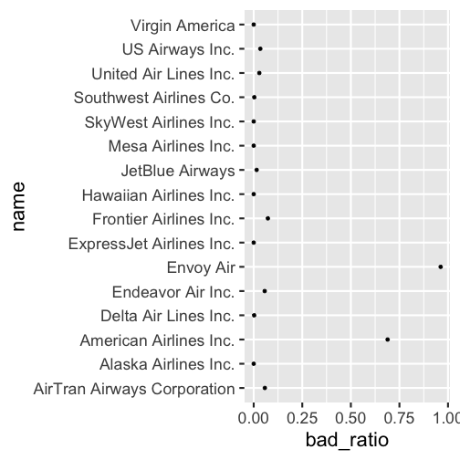

```r
> flight_carrier_count %>%
>   left_join(bad_flight_carrier_count,
>             by="carrier",
>             suffix=c("_all", "_bad")) %>%
>   replace_na(list(n_bad=0)) %>%
>   mutate(bad_ratio = n_bad/n_all) %>%
>   left_join(airlines, by="carrier") %>%
> ggplot(aes(y=name, x=bad_ratio)) +
>   geom_point()
```

- Envoy Air and American Airlines are the culprits!

## More about ggplot2

### Distinguishing groups in plots

```r
> head(orange, 3)
# A tibble: 3 × 3
  Tree    age circumference
  <ord> <dbl>         <dbl>
1 1       118            30
2 1       484            58
3 1       664            87
```

- The data frame `orange` contains data on five trees.

### Distinguishing groups in plots

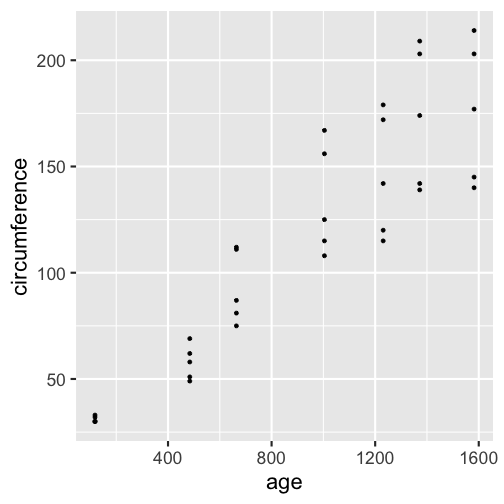

```r
> ggplot(orange, aes(age, circumference)) +
+   geom_point()
```

- If we plot it, we see the data from all the trees in a single plot, but would be better to visually distinguish the different trees

### Example of ggplot2 with color

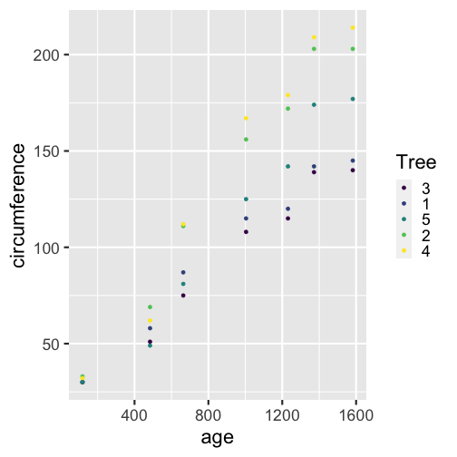

```r
> ggplot(orange, aes(age, circumference)) +
+   geom_point(aes(color = Tree))
```

### Example of ggplot2 with color with larger dots

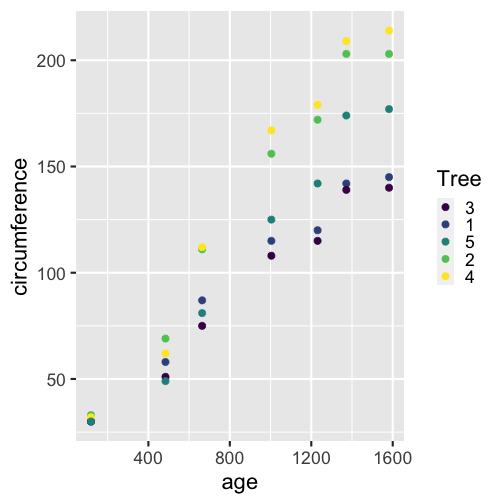

```r
> ggplot(orange, aes(age, circumference)) +
+   geom_point(aes(color = Tree), size=3)
```

- the aesthetics (what's inside of `aes()`) tell ggplot how the columns of the data relate to what should go on the plot
- things that don't relate to the data should go outisde of the call to `aes()`. e.g. `size=3` in this case.
- aesthetics defined in `ggplot()` are passed down to the geoms

### Example of ggplot2 with plot shape

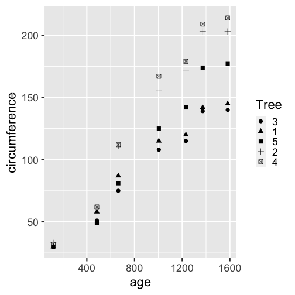

```r
> ggplot(orange, aes(age, circumference)) +
+   geom_point(aes(shape = Tree), size=3)
Warning: Using shapes for an ordinal variable is not advised
```

### Example of ggplot2 with plot color and shape

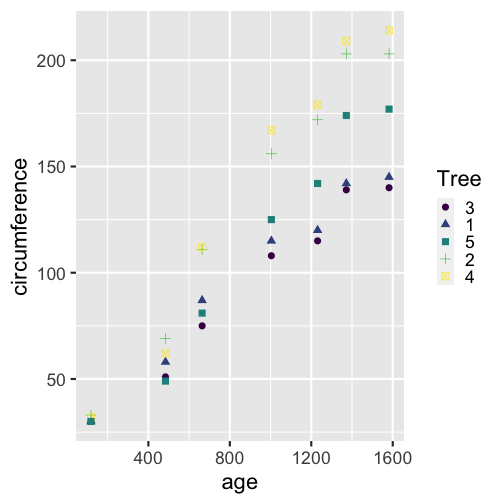

```r
> ggplot(orange, aes(age, circumference)) +
+   geom_point(aes(color = Tree, shape = Tree), size=3)
Warning: Using shapes for an ordinal variable is not advised
```

### Exercise: lines and colors

Reproduce this plot

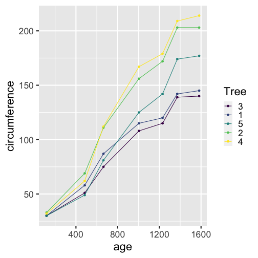

### Answer: lines and colors

```r
> ggplot(orange, aes(age, circumference)) +
+   geom_point(aes(color = Tree)) +
+   geom_line(aes(color = Tree))
```

or

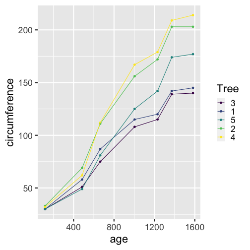

```r
> orange %>%
+ ggplot(aes(age, circumference, color=Tree)) +
+   geom_point() +
+   geom_line()
```

- Recall that the aesthetics in `ggplot` are passed down to the geoms

### Using the loess smoother

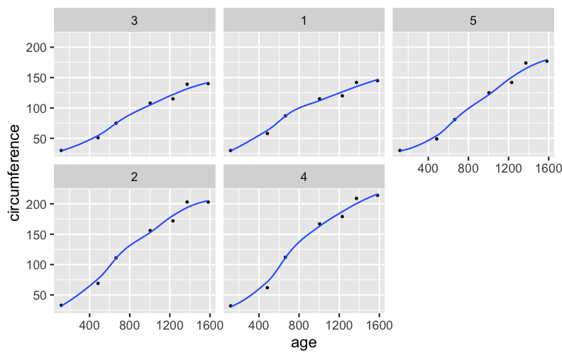

```r
> ggplot(orange, aes(age, circumference)) +
+   geom_point() +
+   facet_wrap(~ Tree) +
+   geom_smooth(method = loess, se = FALSE)
`geom_smooth()` using formula 'y ~ x'
```

### Exercise: loess with color

Reproduce the following plot:

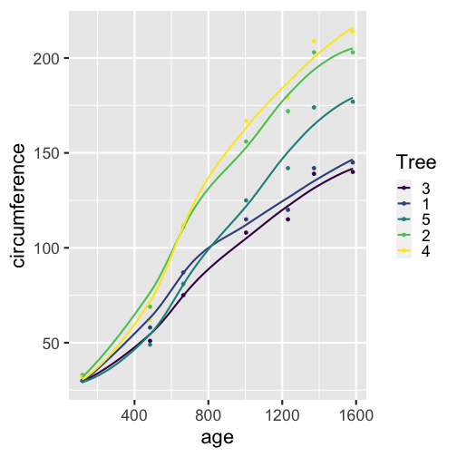

### Answer: loess with color

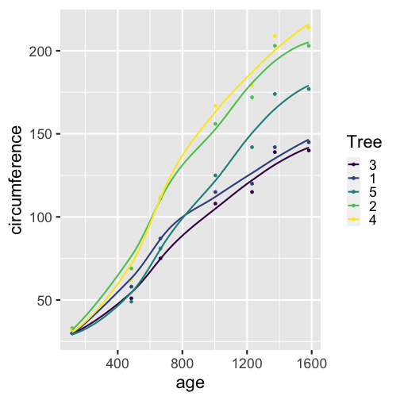

```r
> ggplot(orange, aes(age, circumference, color=Tree)) +
+   geom_point() +
+   geom_smooth(method = loess, se = FALSE)
`geom_smooth()` using formula 'y ~ x'
```

### Aesthetics can be used within each plot element separately

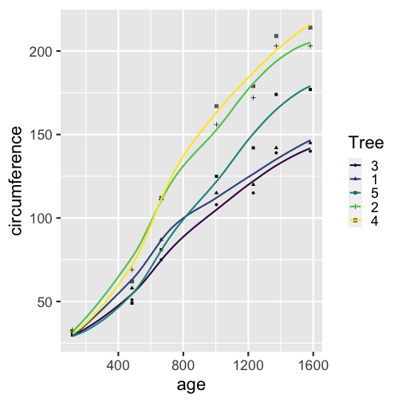

```r
> ggplot(orange, aes(age, circumference)) +
+   geom_point(aes(shape=Tree)) +
+   geom_smooth(aes(color=Tree), method = loess, se = FALSE)
Warning: Using shapes for an ordinal variable is not advised
`geom_smooth()` using formula 'y ~ x'
```

### Facets: multiple aligned plots by group

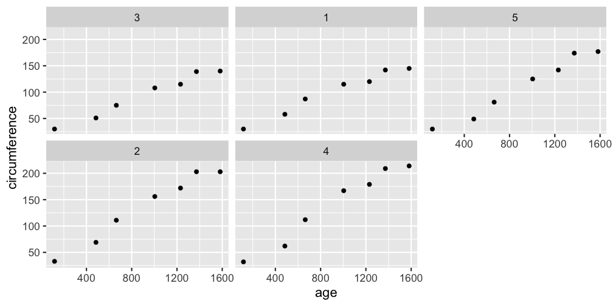

```r
> ggplot(orange, aes(age, circumference)) +
+   geom_point(size = 3) +
+   facet_wrap(~ Tree)
```

### Alternative using facets

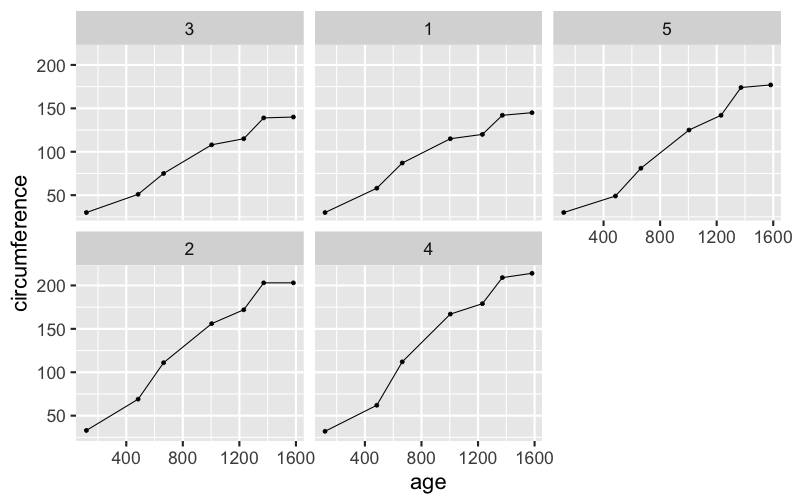

```r
> orange %>%
+ ggplot(aes(age, circumference)) +
+   geom_point() +
+   geom_line() +
+   facet_wrap(~ Tree)
```

### Facet syntax

- `facet_wrap(~ facet_variable)`: This puts the facets left-to-right, top-to-bottom, wrapping around.
- `facet_grid(y-variable ~ .)`: This puts them in a vertically-aligned stack, by value of the y-variable.
- `facet_grid(. ~ x-variable)`: This puts them in a horizontally-aligned stack, by value of the x-variable.

### Facet grid example 1

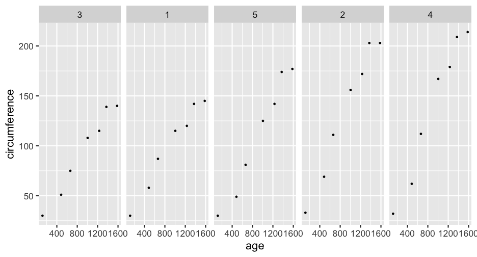

```r
> ggplot(orange, aes(age, circumference)) +
+   geom_point() +
+   facet_grid(. ~ Tree)
```

### Facet grid example 2

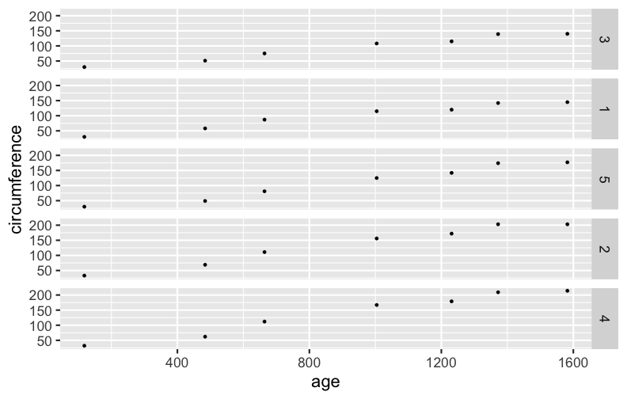

```r
> ggplot(orange, aes(age, circumference)) +
+   geom_point() +
+   facet_grid(Tree ~ .)
```